# Toolik_gth89_Sila Flux Cleaning

Kaj

2025-07-16

# Flux Cleaning

```r
rm(list = ls())

library(data.table)
library(ggplot2)
library(cowplot)
library(openair)
library(plotrix)
library(signal)
library(svMisc)
library(zoo)
library(stringr)
library(plyr)
library(dplyr)
library(purrr)
library(tidyr)
```

Load in eddypro output files

```r
met = fread('C:/Users/klynoe/Documents/toolik/R_outputs/met/biomet_clean.csv')

df = fread('C:/Users/klynoe/Documents/toolik/R_outputs/fluxes_merged_2025_until_09.csv')
#df = fread("C:/Users/klynoe/Documents/toolik/eddypro_output/2025/09/eddypro_09_25_full_output_2025-10-06T120635_adv.csv", skip = 3, header = F, na.strings = c('-9999','NA','NaN','NAN','-7999'))
#h = fread("C:/Users/klynoe/Documents/toolik/eddypro_output/2025/09/eddypro_09_25_full_output_2025-10-06T120635_adv.csv",skip = 1,nrows = 0)

#names(df) = names(h)

df$TIMESTAMP = paste(df$date, df$time)
df$TIMESTAMP = as.POSIXct(df$TIMESTAMP, format = "%Y-%m-%d %H:%M", tz = "UTC")
met$TIMESTAMP <- mdy_hm(met$TIMESTAMP, tz = "UTC")  # month/day/year hour:minute
```

```
## Error in mdy_hm(met$TIMESTAMP, tz = "UTC"): could not find function "mdy_hm"
```

```r
# Ensure TIMESTAMP is in POSIXct format with UTC timezone
df$TIMESTAMP <- as.POSIXct(df$TIMESTAMP, tz = "UTC")

# Filter rows with TIMESTAMP greater than "2024-07-26 16:30:00"
#filter_date <- as.POSIXct("2024-07-26 16:30:00", tz = "UTC")
#filter_date <- as.POSIXct("2024-10-30 16:30:00", tz = "UTC")
#df <- df[!(df$TIMESTAMP <= filter_date), ]
#df <- df[!is.na(df$TIMESTAMP), ]

#met <- met[!(met$TIMESTAMP <= filter_date), ]
#met <- met[!is.na(met$TIMESTAMP), ]


#df= merge(df,met,by='TIMESTAMP',all = T)

#check time stamps to ensure we have a complete series
TIMESTAMP = seq(from = min(df$TIMESTAMP), to = max(df$TIMESTAMP),by = 60*30,tz = "UTC")
tsdf = as.data.frame(TIMESTAMP)

dfs = list(tsdf, df, met)
df = Reduce(function(x, y) merge(x, y, by = "TIMESTAMP", all.x = TRUE), dfs)
```

#Creates a variable to input a date range for the plots in the flux section of #cleaning code. Used to easily change date range for different data sets.

```r
flux_dates <- c("2025-04-31",'2025-10-01')
```

#Create Flags

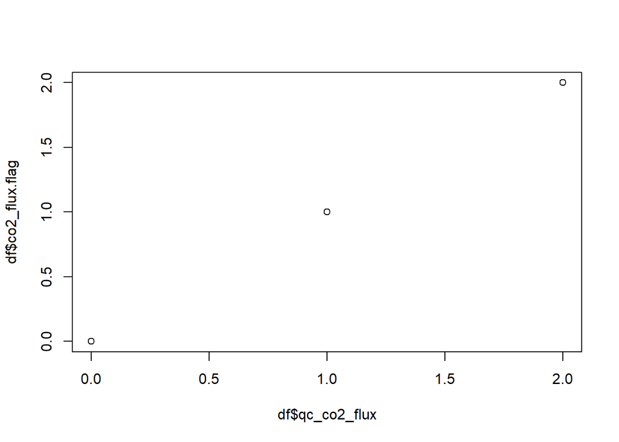

```r
df$Tau.flag <- as.numeric(df$qc_Tau)
df$co2_flux.flag <- as.numeric(df$qc_co2_flux)
df$ch4_flux.flag <- as.numeric(df$qc_ch4_flux)
df$LE.flag <- as.numeric(df$qc_LE)
df$H.flag <- as.numeric(df$qc_H)


#check that it worked
plot(df$qc_co2_flux, df$co2_flux.flag)
```

# Initial Clean

## Energy Balance

combine energy fluxes by met and flux components

```r
df$met = (df$LWIN_1_1_1.c + df$SWIN_1_1_1.c) - (df$LWOUT_1_1_1.c + df$SWOUT_1_1_1.c)
df$flux = df$H + df$LE

plot(df$met, df$flux)
```

```
## Error in plot.window(...): need finite 'xlim' values
```

```r
#add better plot here! with 1:1 line and better axis ratio
```

plot all solar radiation

```r
plot(df$ts,df$SWIN_1_1_1.c)
```

```
## Error in plot.window(...): need finite 'ylim' values
```

```r
plot(df$ts,df$SWOUT_1_1_1.c)
```

```
## Error in plot.window(...): need finite 'ylim' values
```

```r
plot(df$ts,df$LWIN_1_1_1.c,ylim = c(0,800))
plot(df$ts,df$LWOUT_1_1_1.c,ylim = c(0,800))
```

[output not shown]

create and plot mismatch variable between met and flux

```r
#df$mismatch = df$flux/df$met

#mismatch.limits = ifelse(df$mismatch > 10 & df$mismatch < -10, NA,mismatch.limits)

#mismatch.limits = replace(df$mismatch, df$mismatch < -10 | df$mismatch > 10,NA)


#plot(df$ts,mismatch.limits,)
```

plot energy balance

NEED TO REASSESS OR GET RID OF THIS CHUNK —- removes where the energy balance is off by more than a factor of 10, not sure I like this, mostly removes small fluxes where the factor would have a larger relative mismatch

create new variable _.energy

```r
#Tau.energy  = replace(df$Tau ,abs(df$mismatch)>10,NA)
#H.energy    = replace(df$H   ,abs(df$mismatch)>10,NA)
#LE.energy   = replace(df$LE  ,abs(df$mismatch)>10,NA)
#co2_flux.energy   = replace(df$co2_flux  ,abs(df$mismatch)>10,NA)
#ch4_flux.energy = replace(df$ch4_flux,abs(df$mismatch)>10,NA)
```

## EP QC

filter by the eddypro flags and create new variable _.qc

```r
Tau.qc      = replace(df$Tau,df$qc_Tau == 2,NA)
co2_flux.qc = replace(df$co2_flux,df$qc_co2_flux == 2,NA)
ch4_flux.qc = replace(df$ch4_flux,df$qc_ch4_flux == 2,NA)
LE.qc       = replace(df$LE,df$qc_LE == 2,NA)
H.qc        = replace(df$H,df$qc_H == 2,NA)
```

## Clear Outliers

look for absolute outliers and manually set some absolute limits to remove crazy data

### Tau

Plot Tau Histogram

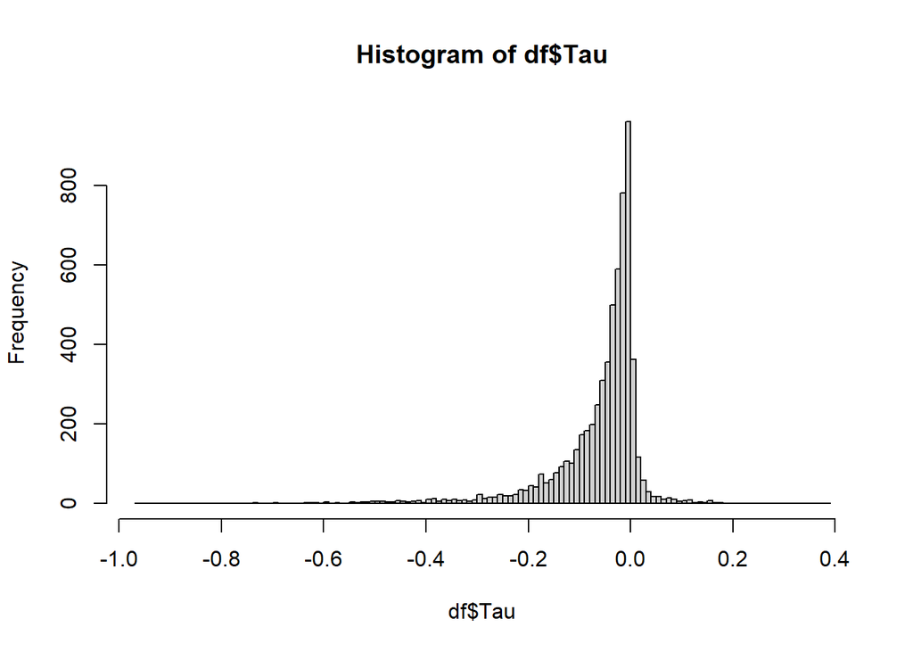

```r
hist(df$Tau,breaks=100)
```

Cut the crazy data and create new variable (Tau.limits)

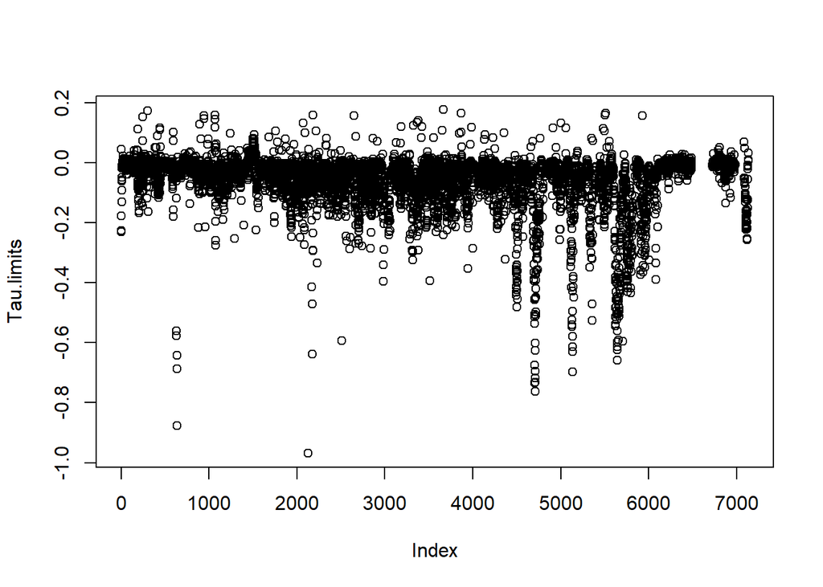

```r
Tau.limits = df$Tau
Tau.limits = replace(df$Tau,df$Tau < -1 | df$Tau > .2,NA)

plot(Tau.limits)
```

### NEE

Plot NEE Histogram and what we might clean

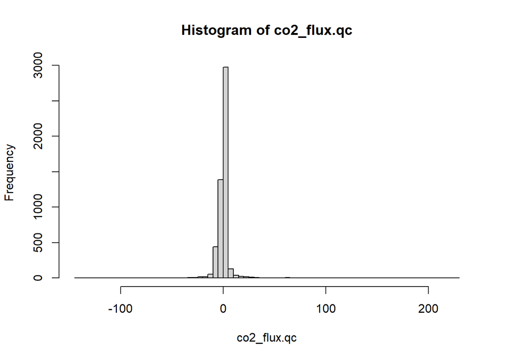

```r
hist(co2_flux.qc,breaks=100)
```

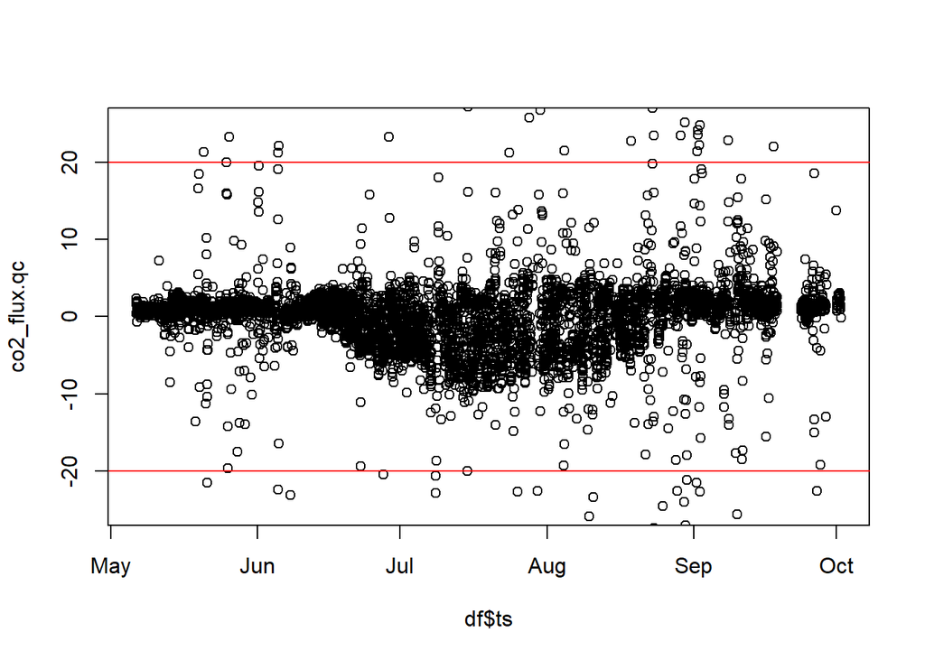

```r
#
plot(df$ts,co2_flux.qc,ylim = c(-25,25));abline(h=20, col= 'red');abline(h=-20, col='red')
```

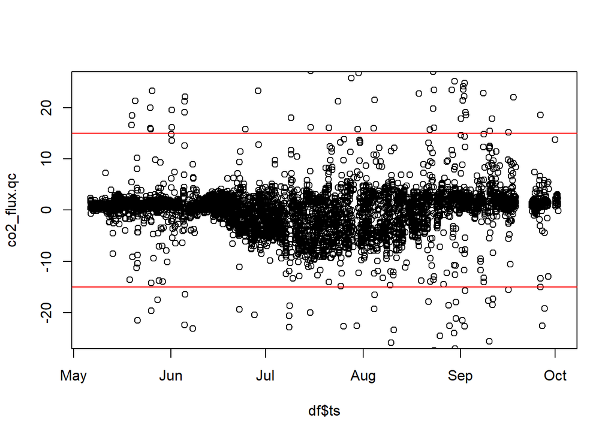

```r
#
plot(df$ts,co2_flux.qc,ylim = c(-25,25));abline(h=15, col= 'red');abline(h=-15, col='red')
```

Clean based on graphs, create new variable (co2_flux.limits), and see cleaned product

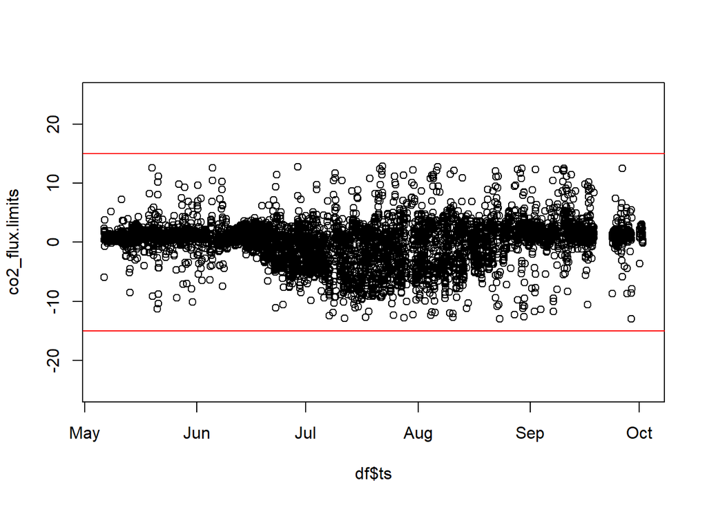

```r
co2_flux.limits = replace(df$co2_flux,(df$co2_flux > 15 | df$co2_flux < -13) & df$TIMESTAMP >= '2025-05-01' | (df$co2_flux > 13 | df$co2_flux < -14),NA)

# Make .flag = 3 everywhere where cleaning is done via absolute limits
df$co2_flux.flag <- ifelse(is.na(co2_flux.limits) & !is.na(df$co2_flux) & df$co2_flux.flag != 2, 3, df$co2_flux.flag)


plot(df$ts,co2_flux.limits,ylim = c(-25,25));abline(h=15, col= 'red');abline(h=-15, col='red')
```

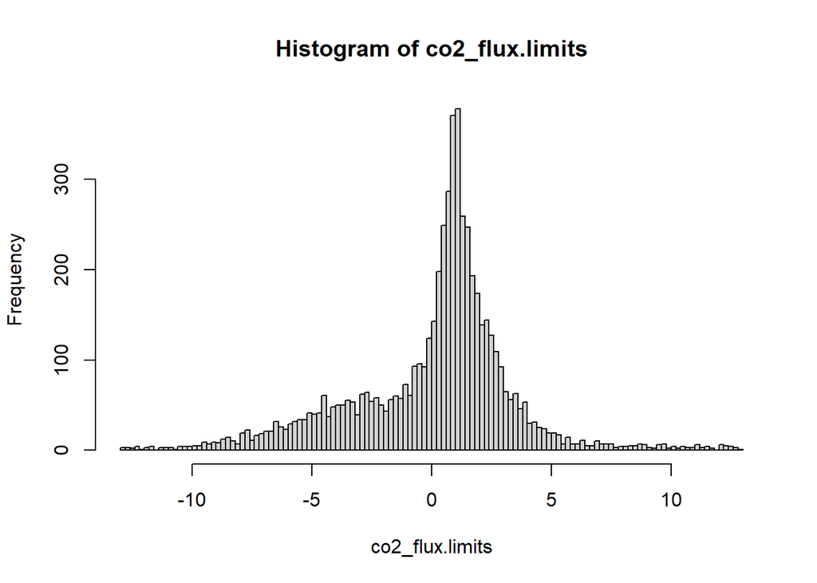

```r
hist(co2_flux.limits,breaks=100)
```

### CH4

Plot CH4 Histogram and what we might clean

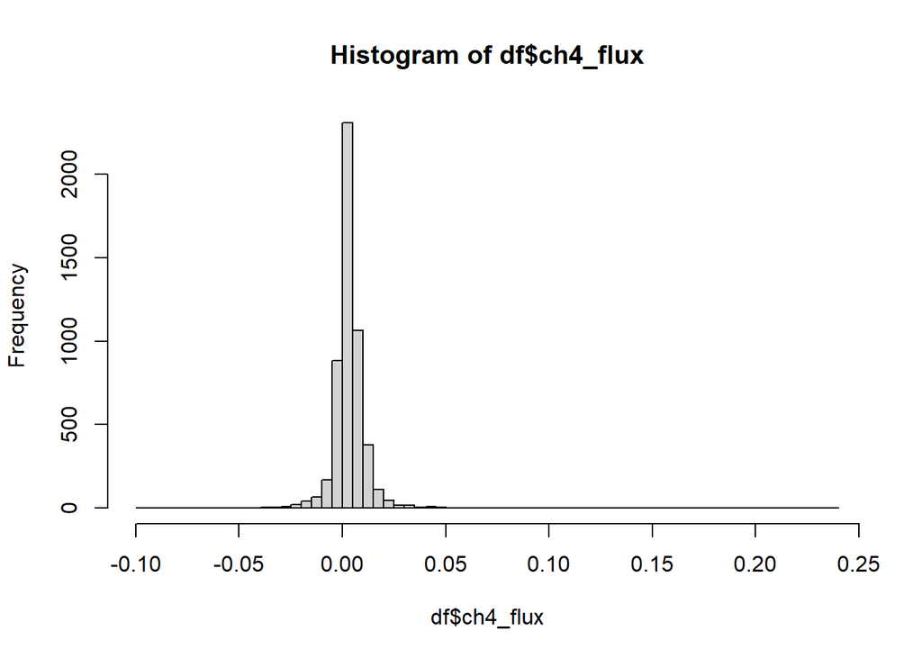

```r
hist(df$ch4_flux,breaks=100)
```

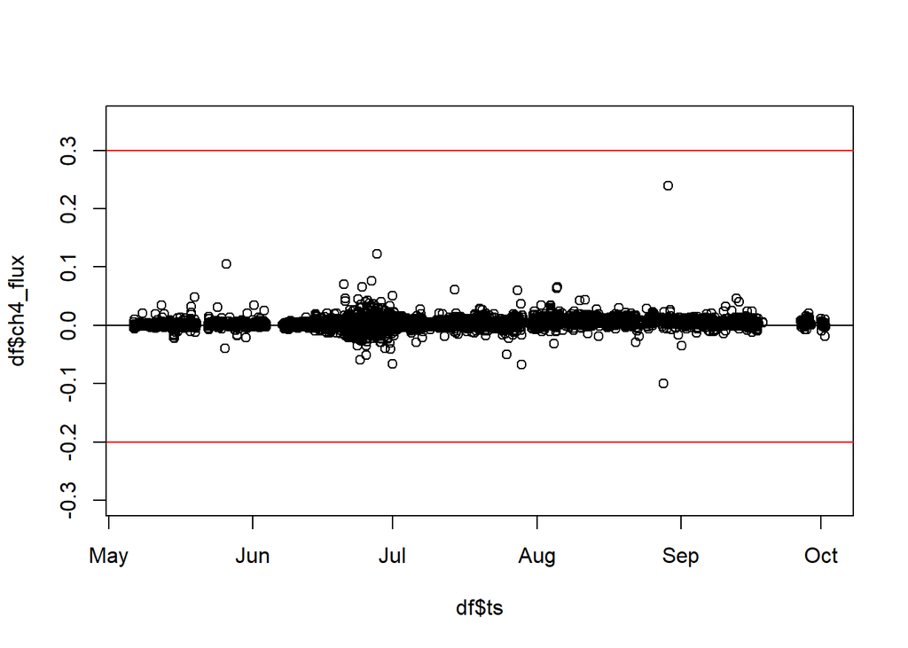

```r
plot(df$ts,df$ch4_flux,ylim = c(-.3,.35));abline(h=.3, col= 'red');abline(h=-.20, col='red'); abline(h=0,col= 'black')
```

Clean based on graphs, create new variable (ch4_flux.limits), and see cleaned product

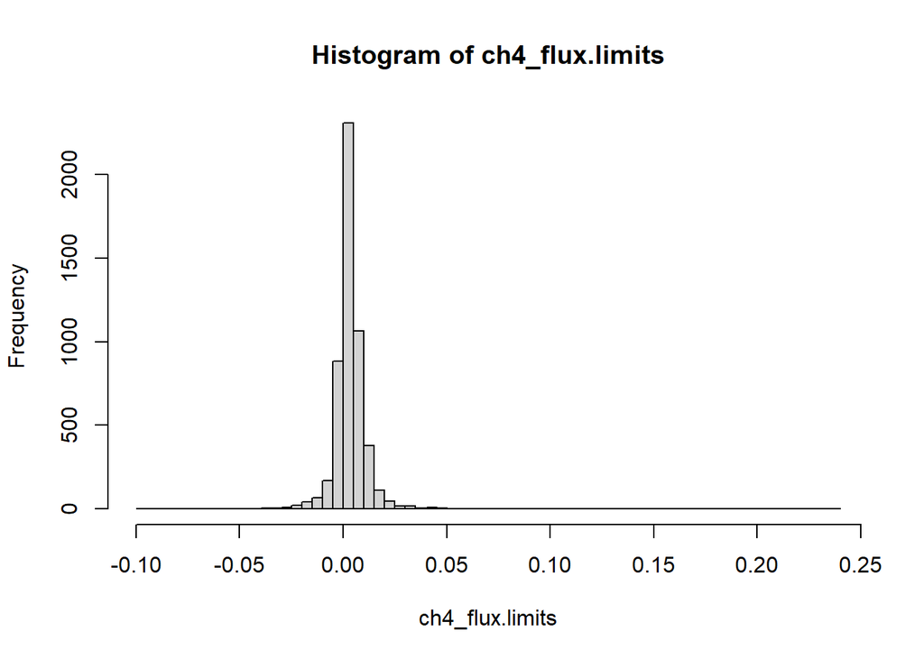

```r
CH4MOLE = ggplot(data = df)+geom_hline(yintercept = 0)+
  geom_point(aes(x=ts,y=ch4_mole_fraction))+
  #geom_vline(xintercept = as.POSIXct('2024-7-26 16:30'),col = 'red')+
  #geom_vline(xintercept = as.POSIXct('2024-12-01 11:00'),col = 'red')+
  scale_y_continuous(limits = c(0,4))


ch4_flux.limits = df$ch4_flux

# Make .flag = 3 everywhere where cleaning is done via absolute limits
df$ch4_flux.flag <- ifelse(is.na(ch4_flux.limits) & !is.na(df$ch4_flux) & df$ch4_flux.flag != 2, 3, df$ch4_flux.flag)


hist(ch4_flux.limits,breaks = 100)
```

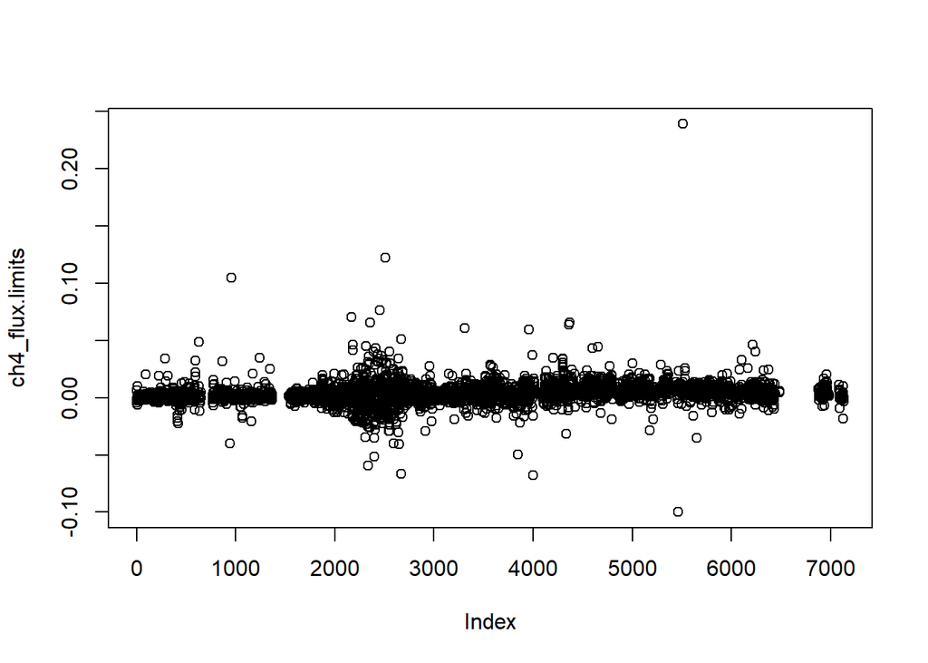

```r
plot(ch4_flux.limits)
```

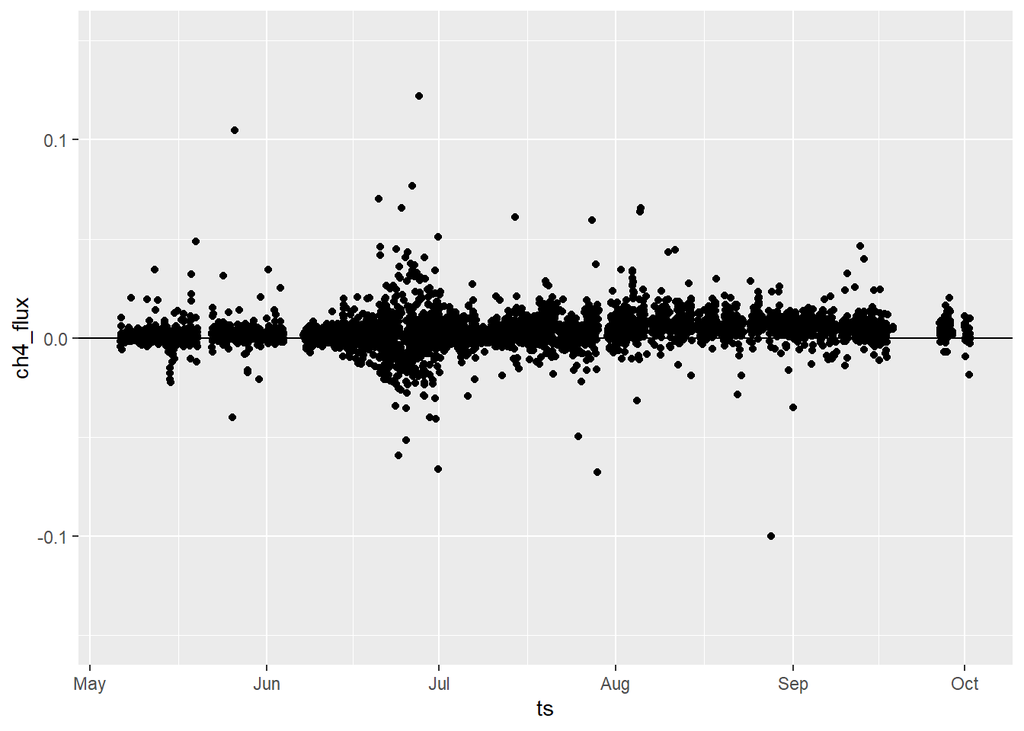

```r
ggplot(data = df)+geom_hline(yintercept = 0)+
  geom_point(aes(x=ts,y=ch4_flux),col = 'red')+
  geom_point(aes(x=ts,y=ch4_flux.limits),col = 'black')+
  scale_y_continuous(limits = c(-.15,.15))
```

### H

Plot H Histogram and what we might clean

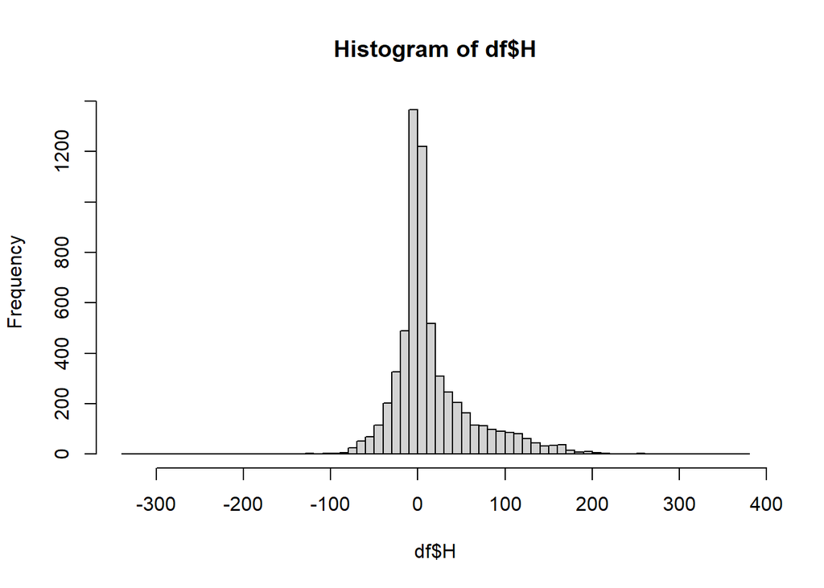

```r
hist(df$H,breaks=100)
```

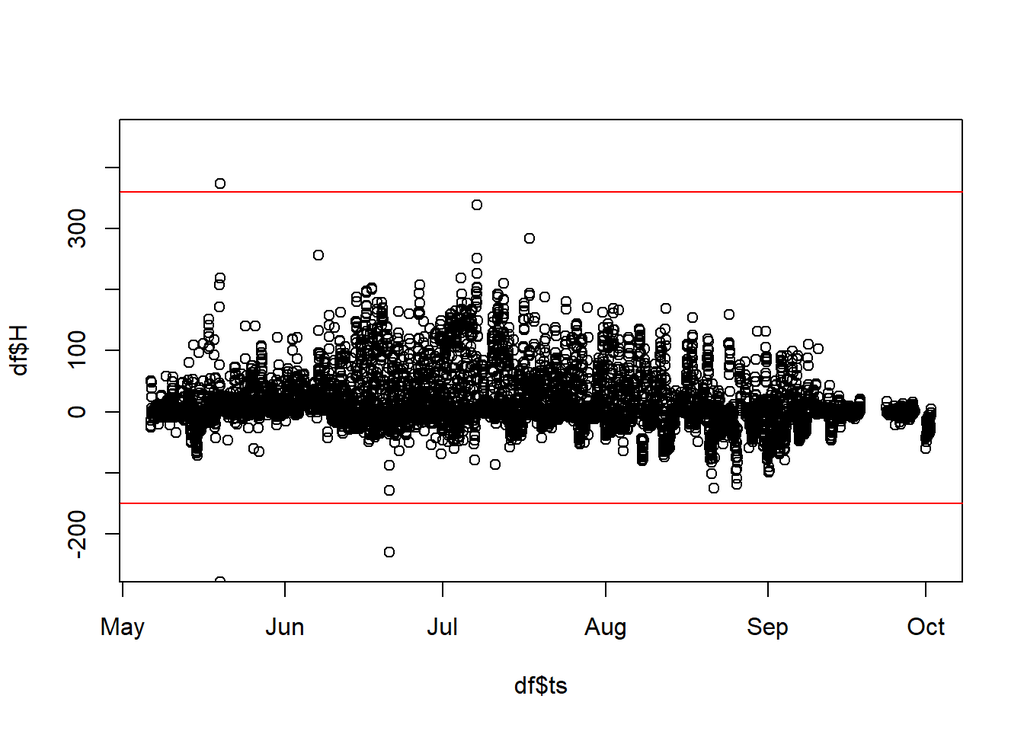

```r
plot(df$ts,df$H,ylim = c(-250,450));abline(h=-150, col= 'red');abline(h=360, col='red')
```

Clean based on graphs, create new variable (H.limits), and see cleaned product

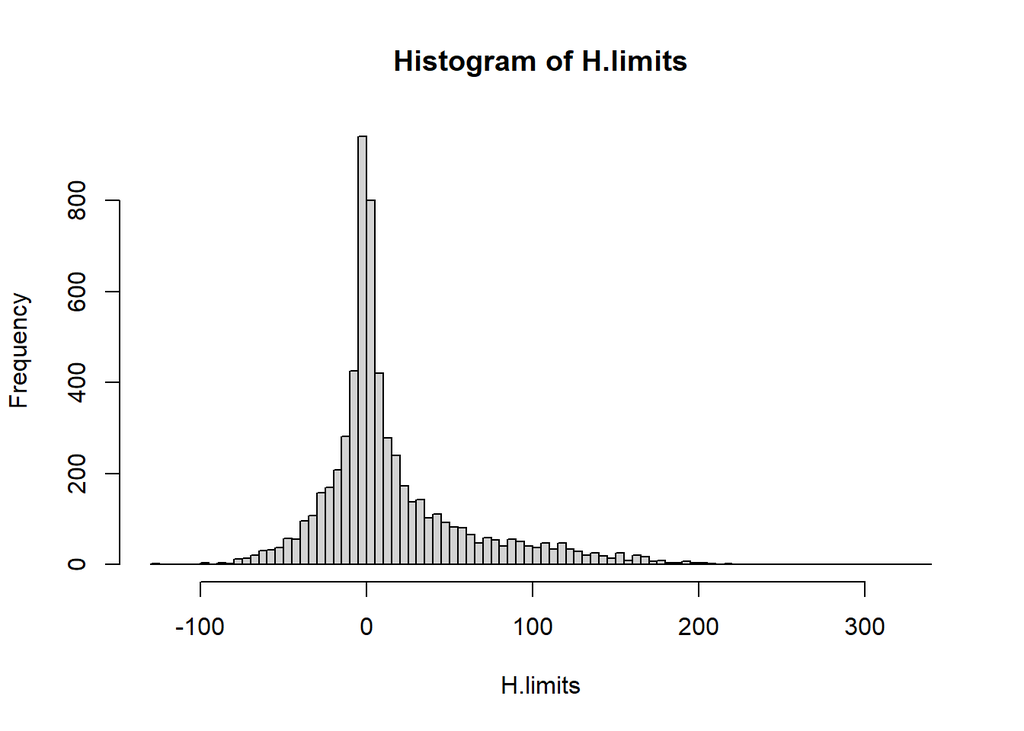

```r
H.limits = replace(df$H, df$H < -150 | df$H > 360,NA)

# Make .flag = 3 everywhere where cleaning is done via absolute limits
df$H.flag <- ifelse(is.na(H.limits) & !is.na(df$H) & df$H.flag != 2, 3, df$H.flag)

hist(H.limits,breaks = 100)
```

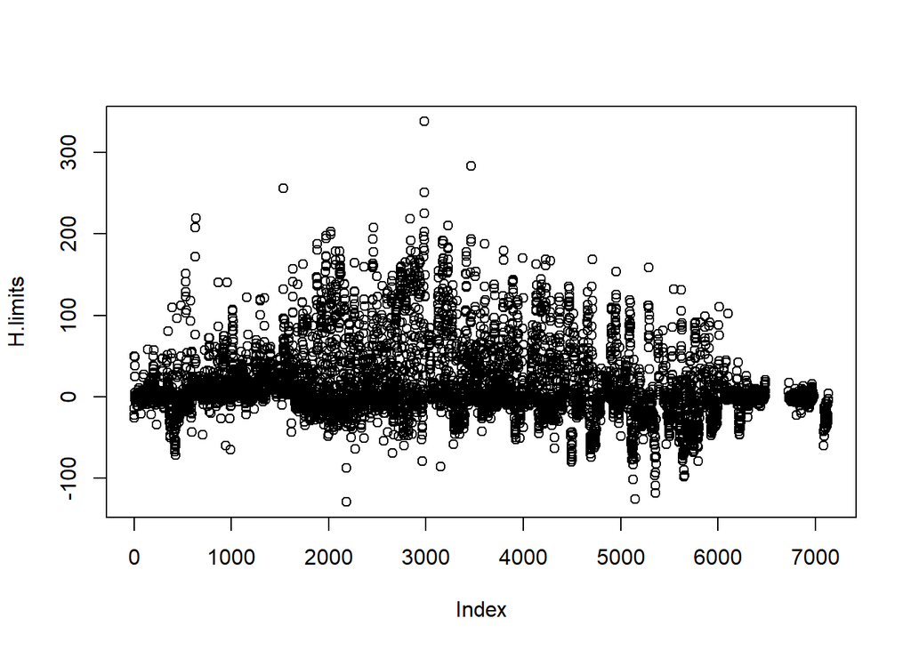

```r
plot(H.limits)
```

### LE

Plot LE Histogram and what we might clean

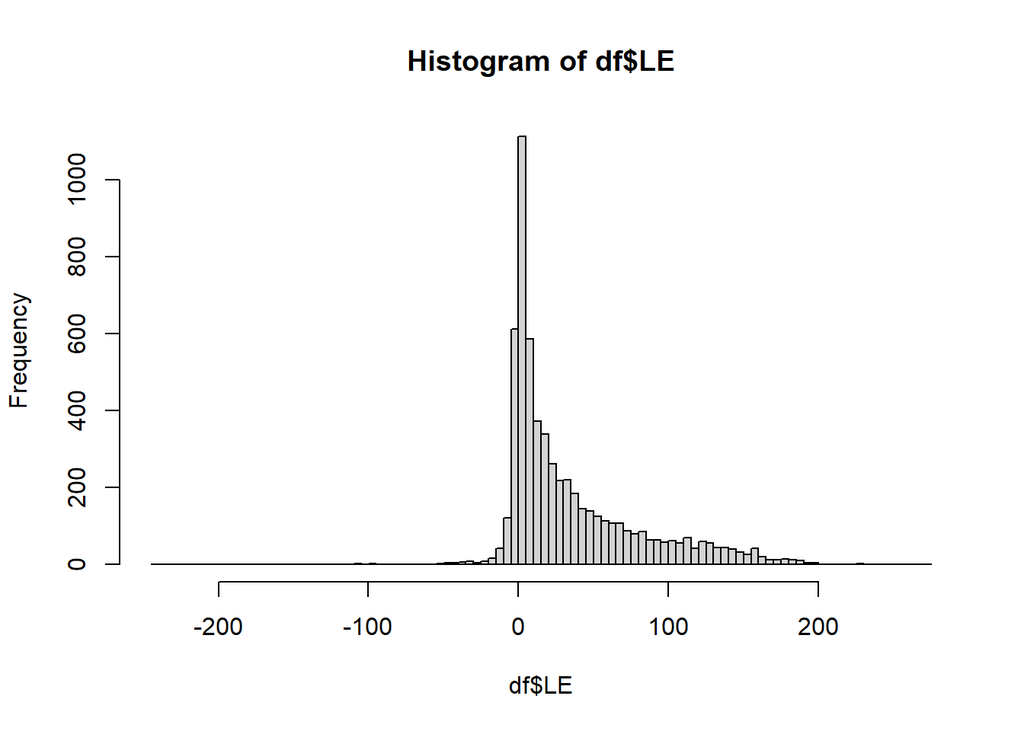

```r
hist(df$LE,breaks=100)
```

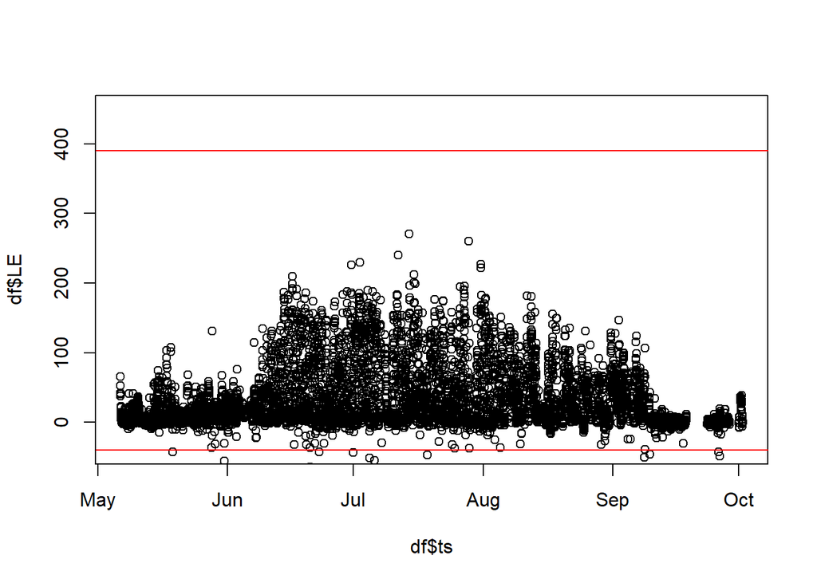

```r
plot(df$ts,df$LE,ylim = c(-40,450));abline(h=-40, col= 'red');abline(h=390, col='red')
```

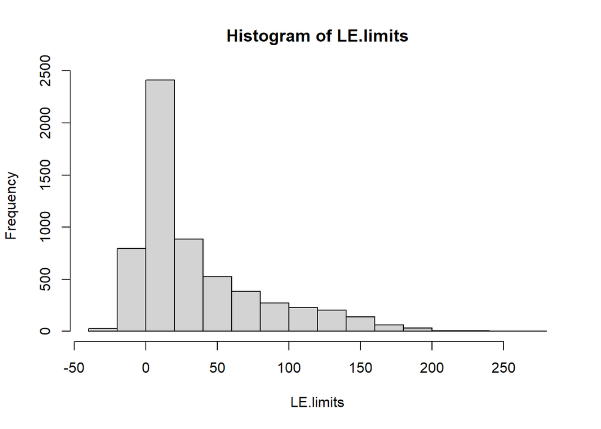

```r
LE.limits = replace(df$LE, df$LE < -40 | df$LE > 390,NA)

# Make .flag = 3 everywhere where cleaning is done via absolute limits
df$LE.flag <- ifelse(is.na(LE.limits) & !is.na(df$LE) & df$LE.flag != 2, 3, df$LE.flag)

hist(LE.limits)
```

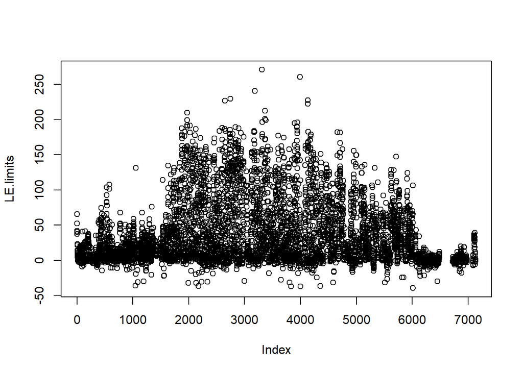

```r
plot(LE.limits)
```

## USTAR

use night-time only flux values and plot Ustar based on data drop off

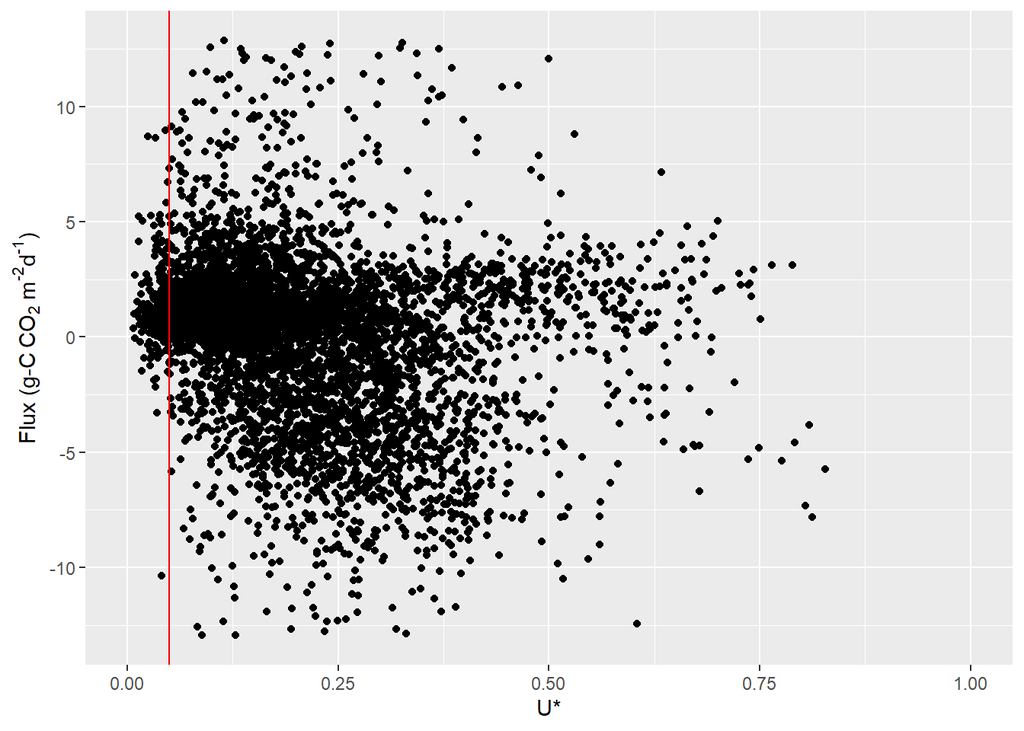

```r
df$nightCO2 = co2_flux.limits
df$nightCO2 = replace(df$nightCO2,df$SWIN_6_10_1_1_1 > 5,NA)

Uthreshold=0.05
ggplot(data = df,aes(`u*`,nightCO2))+
  ylab(expression(paste("Flux (g-C", ~CO[2], ~"m",""^"-2","d",""^"-1",")")))+
  geom_point()+xlab("U*")+
  scale_x_continuous(limits = c(0,1))+
  geom_vline(xintercept = Uthreshold,col='red')
```

created flag to indicate where u* values are below our threshold- makes cleaning with u* optional but easy when using cleaned data sets

```r
df$u_flag = ifelse(df$`u*` < Uthreshold,1,0)
```

## Combine Cleaning

investigate the previous limits and combine all to create a new variable (clean), plot to see difference

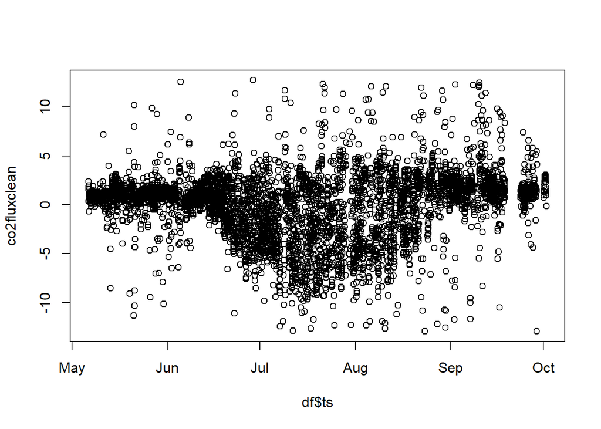

```r
co2fluxclean = ifelse(is.na(co2_flux.qc) | is.na(co2_flux.limits),NA,df$co2_flux)

ch4fluxclean = ifelse(is.na(ch4_flux.qc) | is.na(ch4_flux.limits),NA,df$ch4_flux)

Hclean = ifelse(is.na(H.qc) | is.na(H.limits),NA,df$H)

LEclean = ifelse(is.na(LE.qc) | is.na(LE.limits),NA,df$LE)

Tauclean = ifelse(is.na(Tau.qc) | is.na(Tau.limits),NA,df$Tau)

plot(df$ts,co2fluxclean)
```

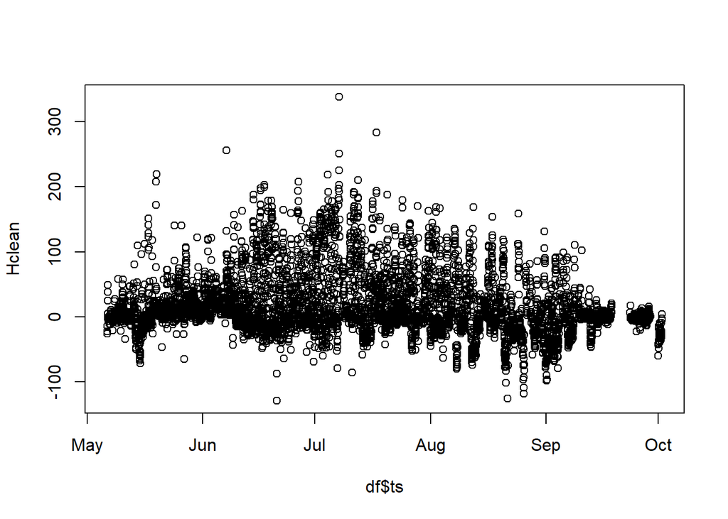

```r
#plot(df$ts,ch4fluxclean)
plot(df$ts,Hclean)
```

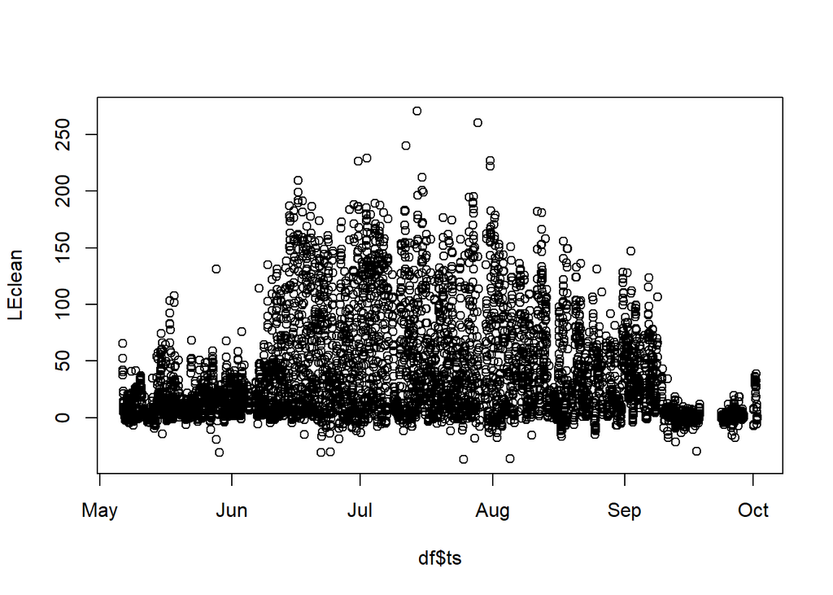

```r
plot(df$ts,LEclean)
```

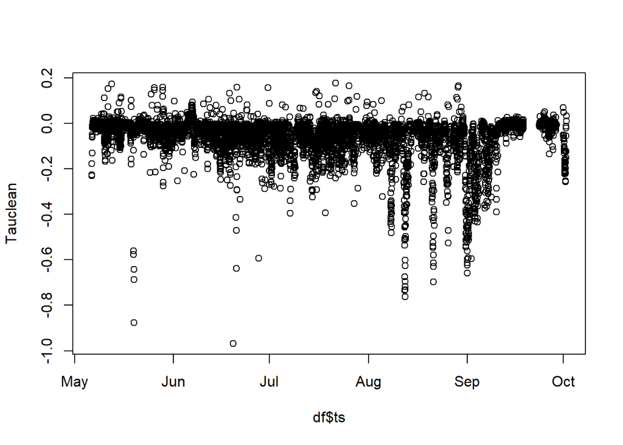

```r
plot(df$ts,Tauclean)
```

Add cleaned tau to dataframe (no MAD filter)

```r
df$Tau.c = Tauclean
```

# MAD Filter

Now, Spike filtering on half-hourly fluxes. For this type of data, filters based on median rather than std perform better. Use Unsymmetric Distributions and double MAD -MAD=Median Absolute Deviation for more info see link below https://eurekastatistics.com/using-the-median-absolute-deviation-to-find-outliers/

## NEE

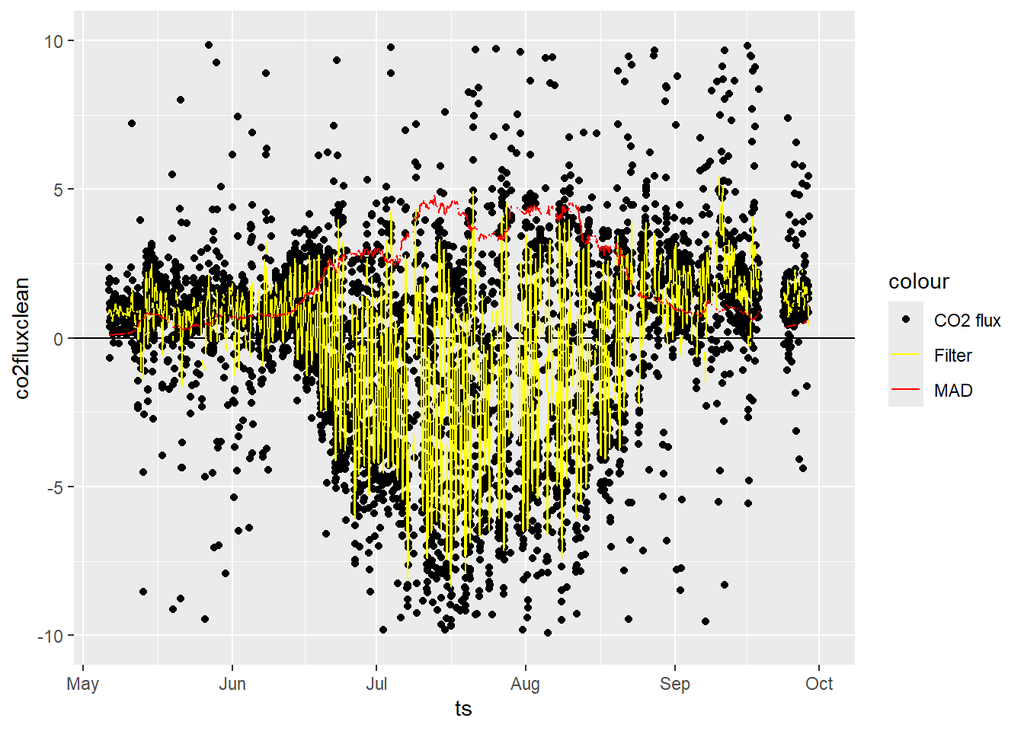

```r
f = co2fluxclean # first make a new flux vector to apply the above filters
# prepare the inputs for a zero-phase (forward and reverse) filter
ind       = which(complete.cases(f))   # first save the index of all the NAs
b         = rep(1,8)/8                 # moving average coefficient
a         = 1                          # coefficient of the ARMA filter
Flux_i    = filtfilt(b, a, na.omit(f)) #create a forward and reverse ARMA filter
Flux_filt = f                          # make a copy of the full fluxes again
Flux_filt[ind] = Flux_i                # apply the filter where the real data exist

n = 7*48 # set the length of the rolling filter, 48 half hours in day * x days
roll.mad = rollapply(data = Flux_filt,
                     width = n,
                     FUN = mad,
                     partial = TRUE,
                     na.rm = T,
                     fill = NA)  #create a rolling MAD or sd or other
roll.mad[is.na(Flux_filt)] = NA  #make NA values where NAs exist in the real data

ggplot(df)+geom_hline(yintercept = 0)+
  geom_point(aes(ts,co2fluxclean,col='CO2 flux'))+
  geom_line(aes(ts,Flux_filt,col='Filter'))+
  geom_line(aes(ts,roll.mad,col='MAD'))+
  scale_y_continuous(limits = c(-10,10))+
  scale_x_datetime(limits = as.POSIXct(flux_dates,format="%F"))+
  scale_color_manual(values=c('black','yellow','red'))
```

```r
  #geom_vline(xintercept = as.POSIXct('2024-01-01'))
```

now filter the data based on this signal

```r
#adjust this value (N) to tweak how many MADs to be away from the norm
N =3

#Add clean value to dataframe (_.c)

df$co2_flux.c = ifelse(abs(co2fluxclean - Flux_filt) > (N * roll.mad),NA,co2fluxclean)
```

ADD THE FLAGS

```r
df$co2_flux.flag <- ifelse(is.na(df$co2_flux.c) & !is.na(co2fluxclean) & df$co2_flux.flag != 2 & df$co2_flux.flag != 3, 4, df$co2_flux.flag)

df$co2_flux.flag <- as.factor(df$co2_flux.flag)
summary(df$co2_flux.flag)
```

```
##    0    1    2    3    4 NA's
## 2840 1859  873  183  291 1087
```

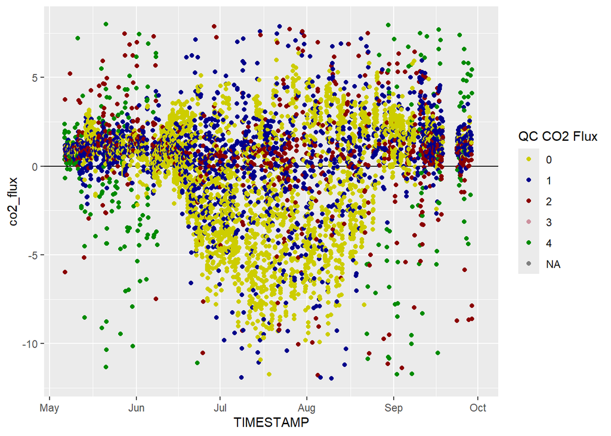

```r
color_map = c("0" = "yellow3", "1" = "darkblue" , "2" =  "red4", "3" = "pink3", "4" = "green4")

ggplot(data = df)+geom_hline(yintercept = 0)+
  geom_point(aes(TIMESTAMP,co2_flux,color = co2_flux.flag))+
  #geom_point(aes(TIMESTAMP,co2_flux.c),col='black')+
  scale_y_continuous(limits=c(-12,8))+
  scale_x_datetime(limits = as.POSIXct(flux_dates,format="%F"))+
scale_color_manual(values = color_map, name = "QC CO2 Flux")
```

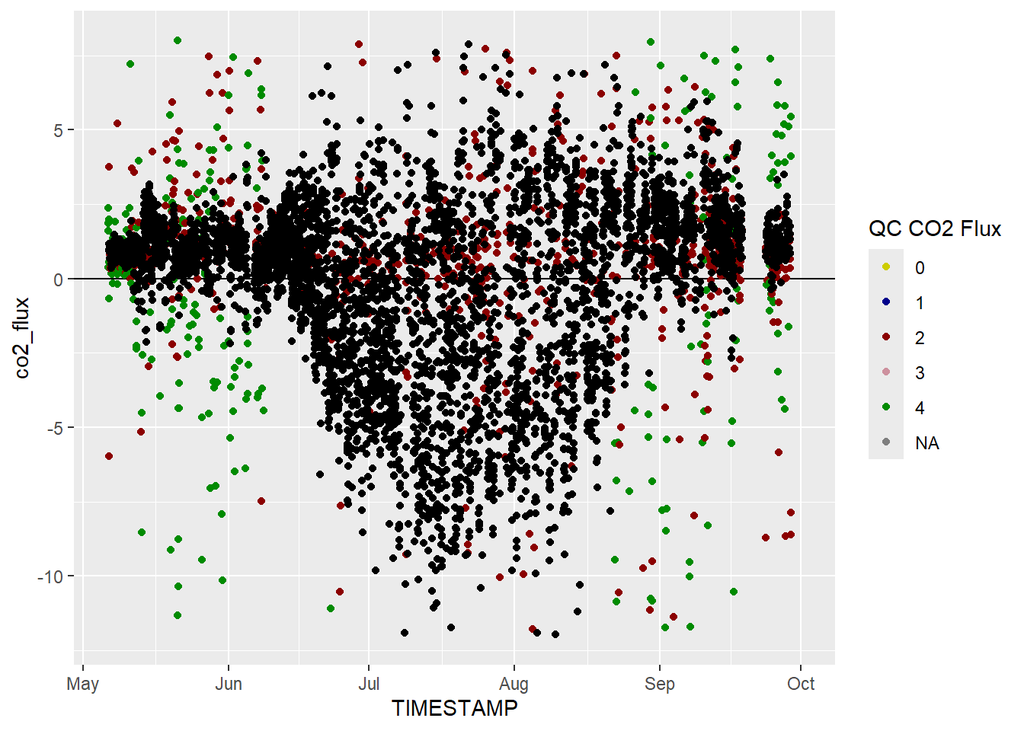

```r
ggplot(data = df)+geom_hline(yintercept = 0)+
  geom_point(aes(TIMESTAMP,co2_flux,color = co2_flux.flag))+
  geom_point(aes(TIMESTAMP,co2_flux.c),col='black')+
  scale_y_continuous(limits=c(-12,8))+
  scale_x_datetime(limits = as.POSIXct(flux_dates,format="%F"))+
scale_color_manual(values = color_map, name = "QC CO2 Flux")
```

#Compare cleaned vs. uncleaned

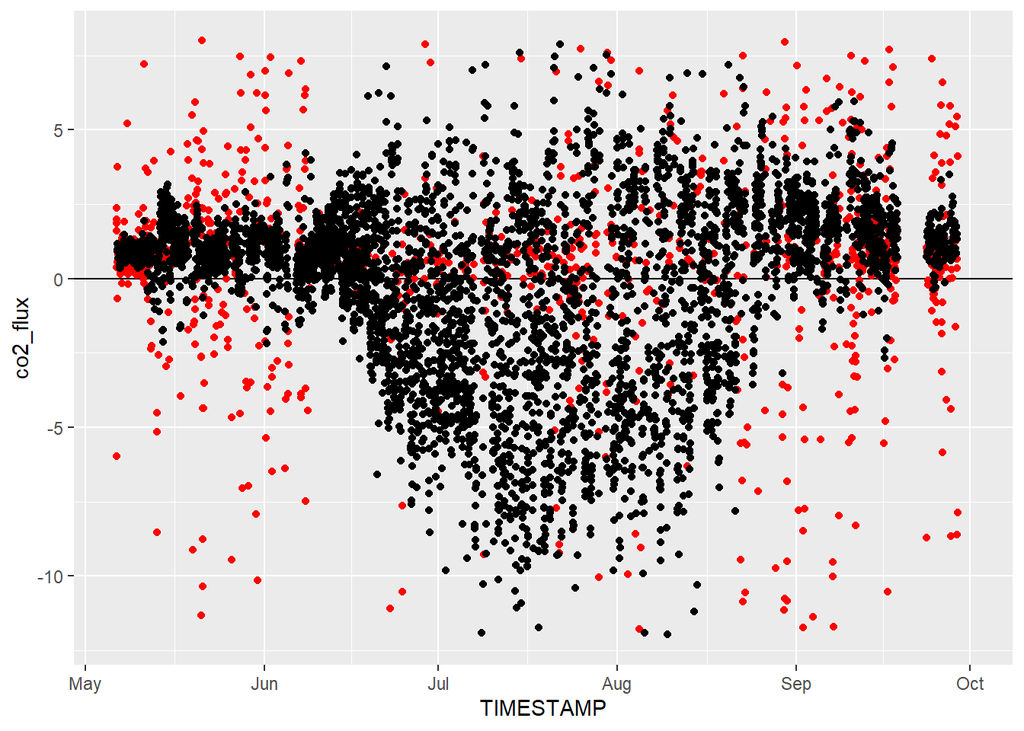

```r
ggplot(data = df)+geom_hline(yintercept = 0)+
  geom_point(aes(TIMESTAMP,co2_flux),col='red')+
  geom_point(aes(TIMESTAMP,co2_flux.c),col='black')+
  scale_y_continuous(limits=c(-12,8))+
    #scale_x_datetime(limits = as.POSIXct(c('2024-09-01','2024-09-12'),format="%F"))
 scale_x_datetime(limits = as.POSIXct(flux_dates,format="%F"))
```

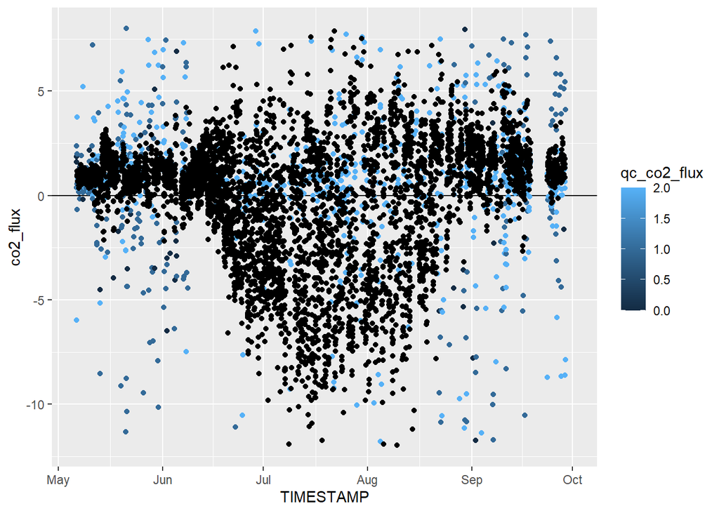

```r
ggplot(data = df)+geom_hline(yintercept = 0)+
  geom_point(aes(TIMESTAMP,co2_flux,colour = qc_co2_flux))+
  geom_point(aes(TIMESTAMP,co2_flux.c),col='black')+
  scale_y_continuous(limits=c(-12,8))+
    #scale_x_datetime(limits = as.POSIXct(c('2024-09-01','2024-09-12'),format="%F"))
 scale_x_datetime(limits = as.POSIXct(flux_dates,format="%F"))
```

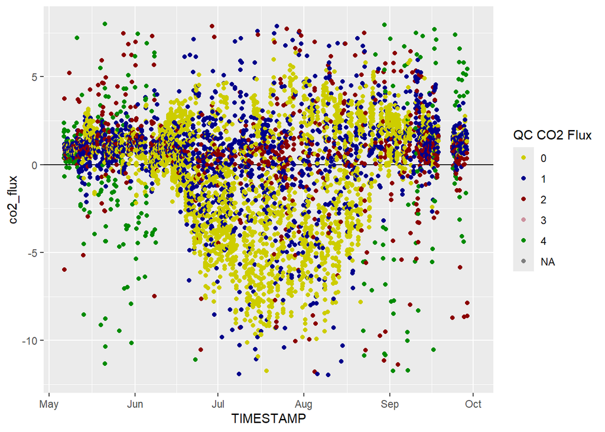

```r
ggplot(data = df)+geom_hline(yintercept = 0)+
  geom_point(aes(TIMESTAMP,co2_flux,color = co2_flux.flag))+
  scale_y_continuous(limits=c(-12,8))+
  scale_x_datetime(limits = as.POSIXct(flux_dates,format="%F"))+
scale_color_manual(values = color_map, name = "QC CO2 Flux")
```